# Predictive Maintenance

Scott Haraburda

December 15, 2022

## Purpose.

To assess equipment failure data through the condition status of in-service equipment for estimating service life expectancy. This is a data-driven, proactive method for predictive maintenance (PdM) that relies upon sensors for early fault or fault detection. For this to work effectively, data from key sensors need to be available and accurately captured for analyses.

## Overview

The overall equipment effectiveness (OEE) for predictive maintenance (PdM) is higher than planned, proactive, preventive maintenance (PM), which is even higher than reactive maintenance (RM)[^1].

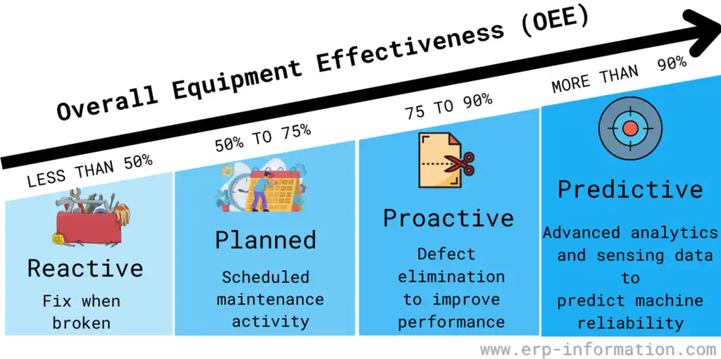

## Data retrieval.

The following code retrieved equipment failure data for 1,000 pieces of equipment from four different vendors (A, B, C, D) and located in three different units (A, B, C). This data included measurements from three different indicators, service life, and whether the equipment had failed. In this hypothetical example, the units of the data were not provided.

```r
if (!require("pacman")) install.packages("pacman")
pacman::p_load(dplyr, flextable, ggplot2, sjPlot, survival)
data <- read.table('PdM.csv',sep=',',header=TRUE)
data$unit <- factor(data$unit)
data$vendor <- factor(data$vendor)
ft <- flextable(head(data)) %>%
  theme_vanilla() %>%
  set_caption(caption = as_paragraph(
    colorize(as_b("Equipment Failure Data"), color="blue")))
ft
```

Equipment Failure Data

| equip_no | life | failed | indicator1 | indicator2 | indicator3 | unit | vendor |
| --- | --- | --- | --- | --- | --- | --- | --- |
| A00048 | 85 | 1 | 121.16589 | 102.84139 | 93.0974 | A | A |
| A00370 | 40 | 0 | 114.70067 | 109.09355 | 108.6968 | A | D |
| A00457 | 43 | 0 | 92.01036 | 95.85379 | 114.1714 | A | B |
| A00733 | 82 | 0 | 89.13264 | 108.28124 | 114.6354 | A | A |
| A00910 | 80 | 1 | 99.68204 | 115.84173 | 104.0768 | A | D |
| A01004 | 26 | 0 | 78.66593 | 110.51841 | 111.0785 | A | D |

## Statistical data.

The following code generated useful statistical information (minimums, maximums, medians, means, standard deviations, and quartiles) for the equipment segrated by units and indicators.

```r
ft <- continuous_summary(
  data,
  columns = NULL,
  by = "unit",
  hide_grouplabel = TRUE,
  digits = 3
)
ft <- bg(ft,
         bg="yellow",
         i=10:12,
         j = 7)     # highlight specific table cells
ft <- color(ft,
         color="red",
         i=10:12,
         j = 7)     # color specific table cells
ft
```

| unit | N | min. | q1 | median | q3 | max. | mean | sd | mad | # na |
| --- | --- | --- | --- | --- | --- | --- | --- | --- | --- | --- |
| life |  |  |  |  |  |  |  |  |  |  |
| A | 336 | 4.000 | 35.000 | 58.500 | 76.000 | 103.000 | 55.622 | 25.651 | 30.393 | 0 |
| B | 356 | 4.000 | 35.000 | 62.000 | 80.250 | 102.000 | 57.323 | 27.542 | 31.876 | 0 |
| C | 308 | 4.000 | 30.000 | 58.000 | 74.250 | 96.000 | 52.805 | 26.178 | 28.911 | 0 |
| failed |  |  |  |  |  |  |  |  |  |  |
| A | 336 | 0.000 | 0.000 | 0.000 | 1.000 | 1.000 | 0.366 | 0.482 | 0.000 | 0 |
| B | 356 | 0.000 | 0.000 | 0.000 | 1.000 | 1.000 | 0.421 | 0.494 | 0.000 | 0 |
| C | 308 | 0.000 | 0.000 | 0.000 | 1.000 | 1.000 | 0.403 | 0.491 | 0.000 | 0 |
| indicator1 |  |  |  |  |  |  |  |  |  |  |
| A | 336 | 39.783 | 88.022 | 100.188 | 114.087 | 147.414 | 101.336 | 19.612 | 19.606 | 0 |
| B | 356 | 33.482 | 83.867 | 95.140 | 109.847 | 166.786 | 96.558 | 19.596 | 18.787 | 0 |
| C | 308 | 35.764 | 85.221 | 96.821 | 111.651 | 173.283 | 97.973 | 20.488 | 18.962 | 0 |
| indicator2 |  |  |  |  |  |  |  |  |  |  |
| A | 336 | 70.929 | 92.630 | 99.044 | 105.226 | 128.595 | 99.145 | 10.272 | 9.304 | 0 |
| B | 356 | 58.547 | 92.570 | 99.557 | 106.178 | 123.898 | 99.310 | 10.052 | 9.993 | 0 |
| C | 308 | 73.299 | 92.927 | 99.606 | 106.486 | 123.268 | 99.706 | 9.618 | 10.016 | 0 |
| indicator3 |  |  |  |  |  |  |  |  |  |  |
| A | 336 | 42.280 | 89.041 | 102.150 | 113.853 | 155.384 | 100.626 | 19.819 | 18.548 | 0 |
| B | 356 | 47.641 | 87.182 | 99.281 | 112.287 | 172.544 | 100.310 | 18.901 | 18.628 | 0 |
| C | 308 | 44.059 | 87.265 | 101.090 | 114.645 | 165.170 | 100.999 | 20.306 | 20.297 | 0 |

In this table, highlighted in red, potentially useful information can be extracted such as the maximum value for Indicator 1 for Unit A with a value of 147 is much lower than the value of 173 for Unit C.

## Linear regression model

The following script develops a simple linear regression of the data, predicting the life of each equipment based upon all of the variable attributes in the data, excluding the equipment number.

```r
fit1 <- lm(life ~.-failed,data=data[,(2:8)])
ft <- as_flextable(fit1) %>%
  theme_vanilla() %>%
  set_caption(caption = as_paragraph(
    colorize(as_b("Linear Regression Model"), color="blue")))
ft <- bg(ft,
         i = c(1,8),
         bg="yellow",
         part="body")
ft <- color(ft,
         i = c(1,8),
         color="red",
         part="body")
ft
```

Linear Regression Model

|  | Estimate | Standard Error | t value | Pr(>\|t\|) |  |
| --- | --- | --- | --- | --- | --- |
| (Intercept) | 53.650 | 10.384 | 5.167 | 0.0000 | *** |
| indicator1 | -0.001 | 0.042 | -0.022 | 0.9822 |  |
| indicator2 | 0.013 | 0.083 | 0.151 | 0.8802 |  |
| indicator3 | 0.020 | 0.042 | 0.476 | 0.6341 |  |
| unitB | 1.809 | 2.007 | 0.902 | 0.3675 |  |
| unitC | -3.090 | 2.076 | -1.489 | 0.1369 |  |
| vendorB | 1.844 | 2.304 | 0.800 | 0.4237 |  |
| vendorC | -8.536 | 2.359 | -3.619 | 0.0003 | *** |
| vendorD | 1.721 | 2.371 | 0.726 | 0.4681 |  |

Signif. codes: 0 <= '***' < 0.001 < '**' < 0.01 < '*' < 0.05  
Residual standard error: 26.23 on 991 degrees of freedom  
Multiple R-squared: 0.03064, Adjusted R-squared: 0.02281  
F-statistic: 3.915 on 991 and 8 DF, p-value: 0.0001

Based upon this simple regression model, highlighted in red, only the intercept and Vendor C are statistically significant for the model. Furthermore, the adjusted R2 for this is 0.02, which indicates that this model is not a good fit.

## Survival regression model

Since the linear regression model did not work, another model was needed. Capable to predict the expected duration from one event to another, such as life expectancy, a survival analysis was needed, using a popular technique such as survival regression. The code below applies this model to the same attributes that were used for the linear regression model.

```r
 # dependant variables used in survival regression model with Surv() function
fit2 <- survreg(Surv(data$life, data$failed) ~
                  indicator1 +
                  indicator2 +
                  indicator3 +
                  unit +
                  vendor,
                dist="gaussian",
                data=data)
tab_model(survreg(Surv(life, failed) ~
                  indicator1 +
                  indicator2 +
                  indicator3 +
                  unit +
                  vendor,
                dist="gaussian",
                data=data),
          title = "Survival Regression Model",
          dv.labels = "Life Expectancy")
```

Survival Regression Model

|  | Life Expectancy |  |  |
| --- | --- | --- | --- |
| Predictors | Estimates | CI | p |
| (Intercept) | 73.41 | 66.43 – 80.39 | **<0.001** |
| indicator1 | 0.00 | -0.02 – 0.03 | 0.787 |
| indicator2 | 0.04 | -0.02 – 0.10 | 0.163 |
| indicator3 | 0.00 | -0.02 – 0.03 | 0.747 |
| unit [B] | 1.74 | 0.35 – 3.13 | **0.014** |
| unit [C] | -4.48 | -5.92 – -3.04 | **<0.001** |
| vendor [B] | 13.50 | 11.92 – 15.09 | **<0.001** |
| vendor [C] | -13.02 | -14.50 – -11.53 | **<0.001** |
| vendor [D] | 8.30 | 6.65 – 9.95 | **<0.001** |
| Log(scale) | 1.78 | 1.71 – 1.85 | **<0.001** |
| Observations | 1000 |  |  |
| R<sup>2</sup> Nagelkerke | 0.481 |  |  |

Based upon this summary of the survival regression model, the units and vendors appear to provide a statistical significance in the model. With an R2 of 0.48, this model provides a much better analysis than the simple linear regression one with an R2 of 0.02.

## Forecasting life expectancy

For this PdM effort, we needed to estimate the life expectancy of each piece of equipment based upon the previously-calculated survival regression model. With this life expectancy value, we can use the following code to calculate the remaining life available, followed by ordering the data from least available service life to the most.

```r
failure <- predict(fit2, newdata=data, type="quantile", p=.5)
forecast <- data.frame(failure)
forecast$equip_no <- data$equip_no
forecast$life <- data$life
forecast$failed <- data$failed
forecast$life_expectancy <- forecast$failure - data$life
forecast <- forecast[order(forecast$life_expectancy),]
forecast <- forecast %>%
  select(equip_no, everything())          # move equipment number to first col
priority <- forecast[forecast$failed==0,]
priority <- priority[,c(1,2,3,5)]
ft <- qflextable(head(priority,20)) %>%
  theme_vanilla() %>%
  set_caption(caption = as_paragraph(
    colorize(as_b("Life Expectancy Table"), color="blue"))) %>%
  color(~ life_expectancy <2, color="red")
ft
```

Life Expectancy Table

| equip_no | failure | life | life_expectancy |
| --- | --- | --- | --- |
| B97710 | 79.63339 | 85 | -5.3666106 |
| A28696 | 86.76644 | 92 | -5.2335647 |
| C94555 | 82.22555 | 86 | -3.7744505 |
| A00733 | 78.70189 | 82 | -3.2981124 |
| B07200 | 66.75428 | 70 | -3.2457238 |
| B70317 | 88.83429 | 92 | -3.1657143 |
| C60325 | 87.31969 | 89 | -1.6803115 |
| B28377 | 80.52294 | 82 | -1.4770604 |
| B47025 | 87.80354 | 89 | -1.1964556 |
| A62519 | 64.85075 | 66 | -1.1492474 |
| C05968 | 60.72155 | 61 | -0.2784473 |
| C94381 | 73.76691 | 74 | -0.2330881 |
| C96696 | 87.80377 | 88 | -0.1962316 |
| C73320 | 87.24052 | 87 | 0.2405180 |
| C92957 | 60.37679 | 60 | 0.3767877 |
| C97161 | 60.56372 | 60 | 0.5637156 |
| C22009 | 59.82764 | 58 | 1.8276415 |
| C99089 | 60.94858 | 59 | 1.9485789 |
| B27159 | 88.08299 | 86 | 2.0829868 |
| A90757 | 92.23220 | 90 | 2.2321980 |

Highlighted in red in the above table for those pieces of equipment with less than 2 available life expectancy units, we have 18 pieces out of one thousand that required some level of maintenance or replacement before failure.

## Notes

[^1]: [What is Predictive Maintenance?](https://www.erp-information.com/predictive-maintenance), erp-information.com, September 28, 2022